# Exploration of Prosper Loan Data, by Max Sydow

# Bivariate Analysis

### Talk about some of the relationships you observed in this part of the

investigation. How did the feature(s) of interest vary with other features in  
the dataset?

> I was expecting to see a relationship between income and credit score, and credit score and borrower interest rates. I thought a relationship between credit score and DTI would stand out, but the results make sense in that regardless of how much debt one has some are better at making timely payments than others. It also made sense that those with lower incomes tended to take smaller loan amounts. I was expecting to see a noticable trend in income range vs. borrower rate, but people with lower incomes can still have good credit and vice versa so I shouldn’t be surprised.

### Did you observe any interesting relationships between the other features

(not the main feature(s) of interest)?

> The outliers in the credit score vs borrower rate plot threw me off. Some loan recipients have extremely low credit scores. There must be some other criteria that would explain the wide range in borrower rates. Perhaps the credit scores of co-signers are not included here, or maybe there are some other criteria in Prosper Score that determines these rates.

### What was the strongest relationship you found?

> The strongest relationship is between Prosper Score and Borrower Rate, as the absolute value of r is the closest to 1. It would’ve been nice if incomes were continuous, since it looks like there may be some correlation in those plots.

# Multivariate Plots Section

> Comparing box plot of lower and upper credit score ranges.

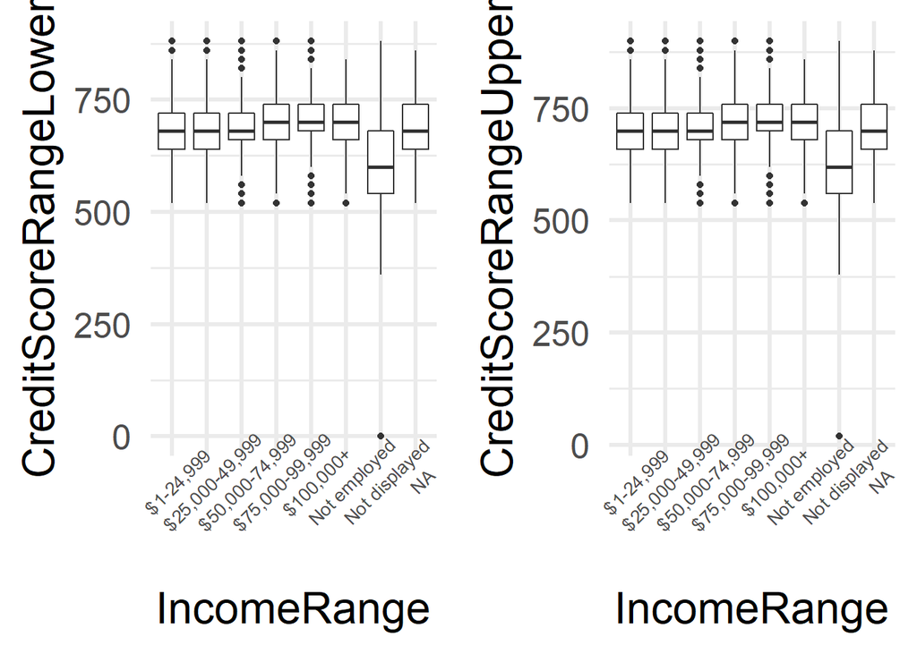

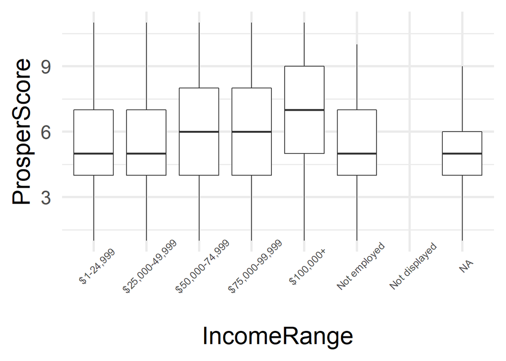

> The trend for Prosper Score rising with income is more noticable. Perhaps Prosper weighs income more heavily in their score than in credit score. The scale for Prosper Score is much narrower, so it’s not wise to jump to this conclusion just yet.

> I want to see if there are any trends regarding loan status in relation to income range.

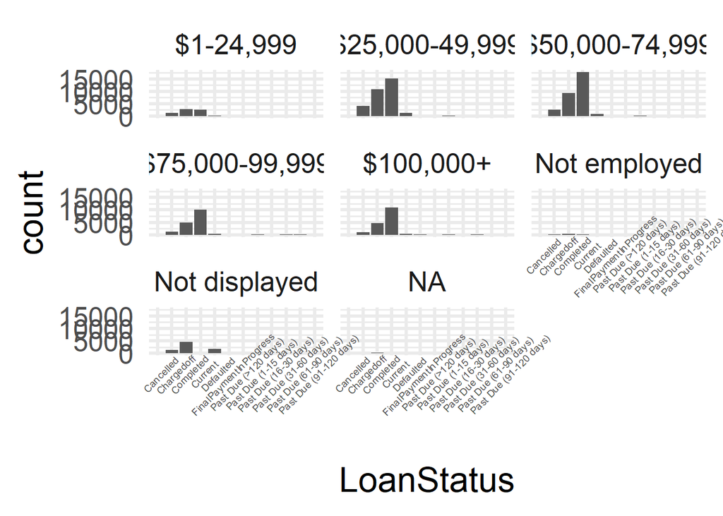

```
## loan$IncomeRange: $0
## NULL
## --------------------------------------------------------
## loan$IncomeRange: $1-24,999
##              Cancelled             Chargedoff              Completed
##                      0                   1329                   2908
##                Current              Defaulted FinalPaymentInProgress
##                   2536                    334                     14
##   Past Due (>120 days)   Past Due (1-15 days)  Past Due (16-30 days)
##                      0                     52                     20
##  Past Due (31-60 days)  Past Due (61-90 days) Past Due (91-120 days)
##                     32                     22                     27
## --------------------------------------------------------
## loan$IncomeRange: $25,000-49,999
##              Cancelled             Chargedoff              Completed
##                      1                   4162                  10891
##                Current              Defaulted FinalPaymentInProgress
##                  15111                   1290                     49
##   Past Due (>120 days)   Past Due (1-15 days)  Past Due (16-30 days)
##                      7                    266                     80
##  Past Due (31-60 days)  Past Due (61-90 days) Past Due (91-120 days)
##                    119                    102                    114
## --------------------------------------------------------
## loan$IncomeRange: $50,000-74,999
##              Cancelled             Chargedoff              Completed
##                      0                   2633                   9282
##                Current              Defaulted FinalPaymentInProgress
##                  17615                    874                     64
##   Past Due (>120 days)   Past Due (1-15 days)  Past Due (16-30 days)
##                      7                    212                     83
##  Past Due (31-60 days)  Past Due (61-90 days) Past Due (91-120 days)
##                     89                     92                     99
## --------------------------------------------------------
## loan$IncomeRange: $75,000-99,999
##              Cancelled             Chargedoff              Completed
##                      0                   1153                   4914
##                Current              Defaulted FinalPaymentInProgress
##                  10139                    375                     26
##   Past Due (>120 days)   Past Due (1-15 days)  Past Due (16-30 days)
##                      1                    131                     37
```

[output cut: 17 more lines]

```
##                    248                     25                      0
##   Past Due (>120 days)   Past Due (1-15 days)  Past Due (16-30 days)
##                      0                      9                      5
##  Past Due (31-60 days)  Past Due (61-90 days) Past Due (91-120 days)
##                      3                      6                      3
## --------------------------------------------------------
## loan$IncomeRange: Not displayed
##              Cancelled             Chargedoff              Completed
##                      4                   1380                   4610
##                Current              Defaulted FinalPaymentInProgress
##                      0                   1747                      0
##   Past Due (>120 days)   Past Due (1-15 days)  Past Due (16-30 days)
##                      0                      0                      0
##  Past Due (31-60 days)  Past Due (61-90 days) Past Due (91-120 days)
##                      0                      0                      0
```

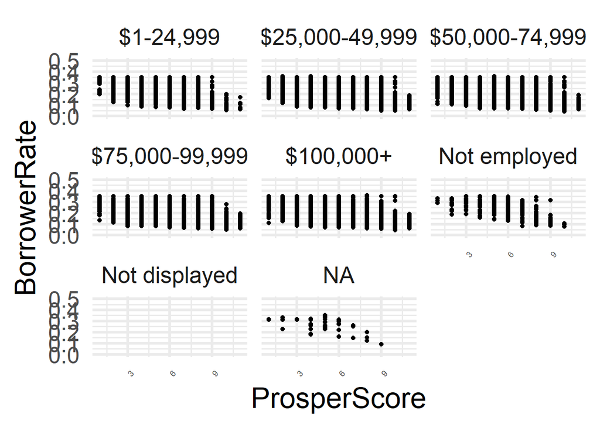

> Along income ranges the same trend of Borrower Rate generally decreasing with Prosper Score seems to hold.

# Multivariate Analysis

### Talk about some of the relationships you observed in this part of the

investigation. Were there features that strengthened each other in terms of  
looking at your feature(s) of interest?

### Were there any interesting or surprising interactions between features?

# Final Plots and Summary

> Of the variables examined so far, there seems to be a more prevalent relationship between Prosper Score and Borrower Rate. These variables will be examined more closely.

### Plot One: Histogram of Borrower Rates

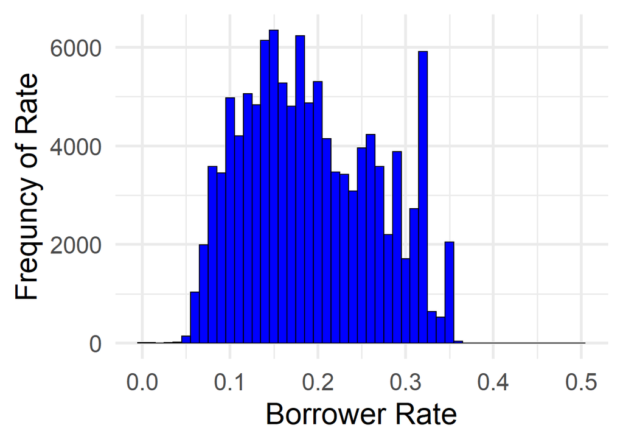

> Box plot of Borrower Rates

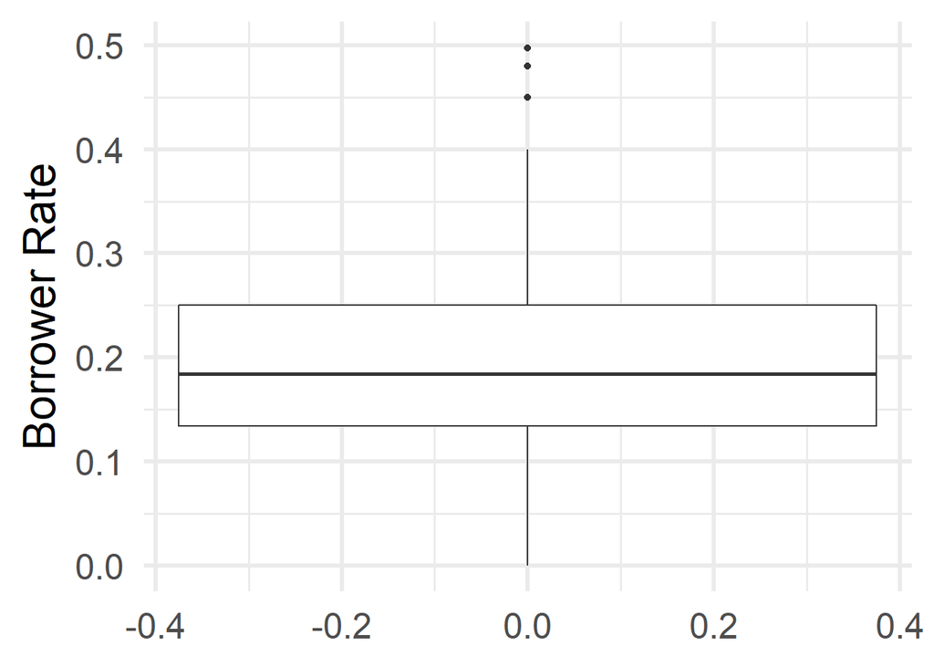

```r
summary(loan$BorrowerRate)
```

```
##    Min. 1st Qu.  Median    Mean 3rd Qu.    Max.
##  0.0000  0.1340  0.1840  0.1928  0.2500  0.4975
```

### Description One

> Adjusting the binwidth on the histogram for Borrower Rate, we still see the increasing trend from 0.25 to 0.35. This suggests a bi-modal distribution. The range of rates is from 0 to 0.4975, with an IQR of 0.116. There are some outliers above rates of 0.4.

### Plot Two: Borrower Rate vs. Prosper Score

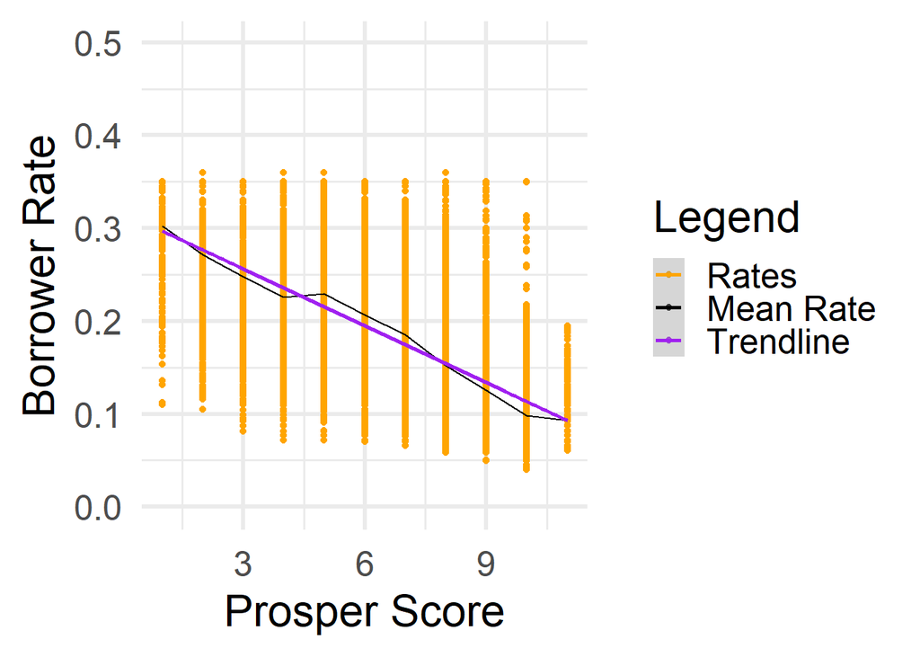

```
##
##  Pearson's product-moment correlation
##
## data:  loan$ProsperScore and loan$BorrowerRate
## t = -248.98, df = 84851, p-value < 2.2e-16
## alternative hypothesis: true correlation is not equal to 0
## 95 percent confidence interval:
##  -0.6536072 -0.6458311
## sample estimates:
##        cor
## -0.6497361
```

### Description Two

> Here we have Borrorwe Rate vs. Prosper Score, overlayed with mean Borrower Rate, and a trendline. The absolute value of r is 0.65, which isn’t very strong, but stronger than other correlations found in the Bivariate Plots section. With the plots of mean Borrower Score and the trendline, it is easy to see the rates decreasing as Prosper Score increases. This makes sense if higher Prosper Scores reflect loan takers general credit worthiness.

### Plot Three: Borrower Rates vs. Prosper Score for each Income Range

```r
levels(loan$IncomeRange)
```

```
## [1] "$0"             "$1-24,999"      "$25,000-49,999" "$50,000-74,999"
## [5] "$75,000-99,999" "$100,000+"      "Not employed"   "Not displayed"
```

```r
loan$IncomeRangeMon <- ordered(loan$IncomeRange, levels = c('$0', '$1-24,999', '$25,000-49,999',                                                                      '$50,000-74,999', '$75,000-99,999',                                                                        '$100,000+'))
```

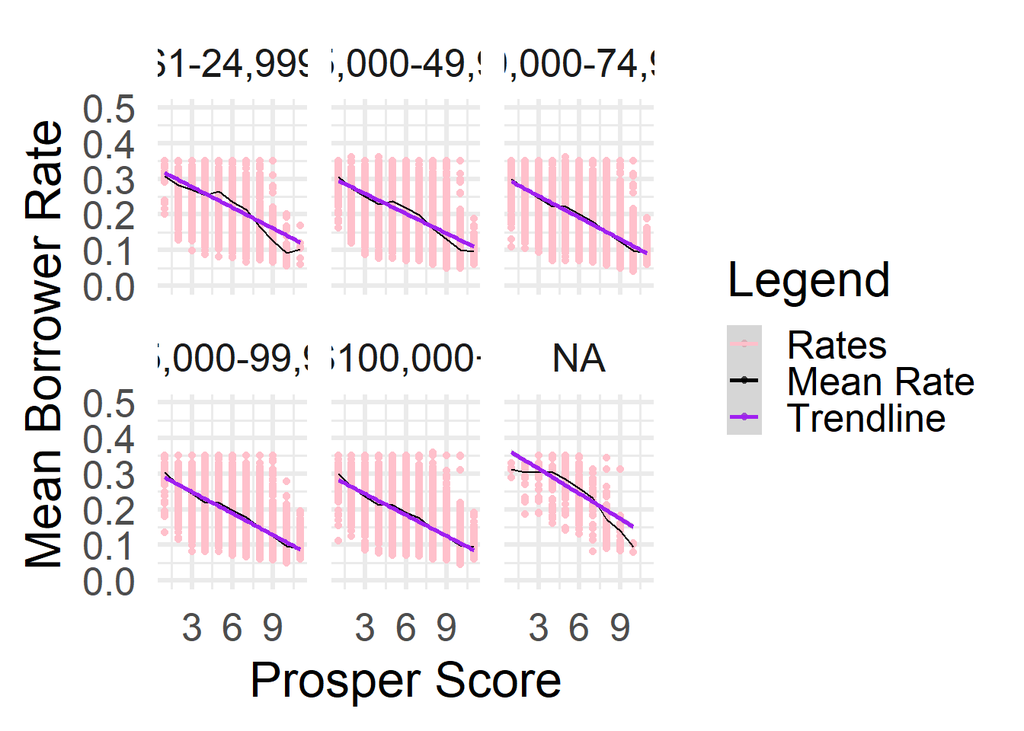

```
##
##  Pearson's product-moment correlation
##
## data:  BorrowerRate and ProsperScore
## t = -46.155, df = 4652, p-value < 2.2e-16
## alternative hypothesis: true correlation is not equal to 0
## 95 percent confidence interval:
##  -0.5798373 -0.5404132
## sample estimates:
##        cor
## -0.5604427
```

```
##
##  Pearson's product-moment correlation
##
## data:  BorrowerRate and ProsperScore
## t = -106.56, df = 24173, p-value < 2.2e-16
## alternative hypothesis: true correlation is not equal to 0
## 95 percent confidence interval:
##  -0.5738542 -0.5566996
## sample estimates:
##       cor
## -0.565338
```

```
##
##  Pearson's product-moment correlation
##
## data:  BorrowerRate and ProsperScore
## t = -133.98, df = 25625, p-value < 2.2e-16
## alternative hypothesis: true correlation is not equal to 0
## 95 percent confidence interval:
##  -0.6489805 -0.6345803
## sample estimates:
##       cor
## -0.641837
```

```
##
##  Pearson's product-moment correlation
##
## data:  BorrowerRate and ProsperScore
## t = -109.11, df = 14496, p-value < 2.2e-16
## alternative hypothesis: true correlation is not equal to 0
## 95 percent confidence interval:
##  -0.6803685 -0.6624915
## sample estimates:
##        cor
## -0.6715277
```

```
##
##  Pearson's product-moment correlation
##
## data:  BorrowerRate and ProsperScore
## t = -120.14, df = 15203, p-value < 2.2e-16
## alternative hypothesis: true correlation is not equal to 0
## 95 percent confidence interval:
##  -0.7059275 -0.6896176
## sample estimates:
##       cor
## -0.697863
```

```r
r <- c(-0.56, -0.56, -0.64, -0.67, -0.7)
income <- c('$1-24,999', '$25,000-49,999', '$50,000-74,999', '$75,000-99,999', '$100,000+')
corr.df <- data.frame('IncomeRange' = income, 'r' = r)

corr.df
```

```
##      IncomeRange     r
## 1      $1-24,999 -0.56
## 2 $25,000-49,999 -0.56
## 3 $50,000-74,999 -0.64
## 4 $75,000-99,999 -0.67
## 5      $100,000+ -0.70
```

### Description Three

> Here I plotted Brorrower Rate vs. Prosper Score for each non-zero income range. The patterns are similar in that the rate decreases as score increases. Looking at Pearson’s correlation coefficient for each, we see that the correlation becomes stronger as income range rises. Finally in the $100,000+ range the correlation of -.7 is strong enough to say that there is a correlation. It would seem that whichever other factors that go into determining the borrower rate don’t play as much of a role for higher earning loan takers.

# Reflection

> I ended up looking at this more from a consumer stand point, examining aspects such as credit score, income range, loan amount, employment status, and interest rates. I was hoping to find a relationship between credit score and interest rate, but ended up finding better correlation using Prosper Score instead. These correlations weren’t very strong though.

> Out of the 82 variables in this data set, I only looked at 18. Perhaps other relationships exist among such variables as Estimated Return, LenderYield, IsBorrowerHomeowner, OpenCreditLines that weren’t included in my subset. Expanding on the analysis already performed I think that the IsBorrowerHomeowner variable would’ve been a good one to look at in terms of credit scores and interest rates.